# Assign4JMT

Johnson Mawuli

2023-04-02

PART 1

```r
 library(readr)

red <- read_delim("~/Downloads/winequality/winequality-red.csv",
     delim = ";", escape_double = FALSE, trim_ws = TRUE, show_col_types = FALSE)

white <- read_delim("~/Downloads/winequality/winequality-white.csv",
     delim = ";", escape_double = FALSE, trim_ws = TRUE, show_col_types = FALSE)
```

```r
library(dplyr)
## applying the prepocessing steps
## checking for any NAS
anyNA(red)
```

```
## [1] FALSE
```

```r
anyNA(white)
```

```
## [1] FALSE
```

```r
# there are not NAs in our data
```

PART 2 using dataset with only white wines

```r
library(randomForest)
library(rpart)
library(ISLR)
library(dplyr)

wwds <- white
rwds <- red

white1 <- rename(wwds, "fixedacidity" = "fixed acidity",
                "volatileacidity" = "volatile acidity",
                "citricacid" = "citric acid",
                "residualsugar" = "residual sugar",
                "freesulfur" = "free sulfur dioxide",
                "totalsulfur" = "total sulfur dioxide")

red1 <- rename(rwds, "fixedacidity" = "fixed acidity",
                "volatileacidity" = "volatile acidity",
                "citricacid" = "citric acid",
                "residualsugar" = "residual sugar",
                "freesulfur" = "free sulfur dioxide",
                "totalsulfur" = "total sulfur dioxide")
## got rid of the spaces in the variables
```

A. Regression Problem 1. Consider the outcome variable quality as a continuous numerical variable. 2. Identify the most important predictors. 3. Report the final verdict by using the test set. (Compare it with a parametric model)

```r
n <- 5
B <- 100

RMSPE <-c()
lm_rmse <- c()

for (i in 1:n) {
ind <- sample(nrow(white1), nrow(white1), replace = TRUE)
train <- white1[ind, ]
test <- white1[-ind, ]

model1 <- randomForest(quality ~., ntree = B, data = train) # RF
yhat1 <- predict(model1, test)
RMSPE[i] <- sqrt(mean((test$quality - yhat1)^2))

# localImp = TRUE
## comparing with parametric model
lm_model <- lm(quality ~ ., data=train) ##what about glm
lm_pred <- predict(lm_model, test)
lm_rmse[i] <- sqrt(mean((lm_pred - test$quality)^2))
}

#average of RMSPE AND LM MODEL
mean(RMSPE)
```

```
## [1] 0.623408
```

```r
mean(lm_rmse)
```

```
## [1] 0.7556108
```

```r
##RF generates a small error which makes it a better model
```

From the regression problem, the random forest model is way better than the parametric model. Since we want to decrease the error in the prediction, we will use the model with a lower RMSPE and the random forest gave us a value lesser than the parametric model

```r
library(randomForestExplainer)
```

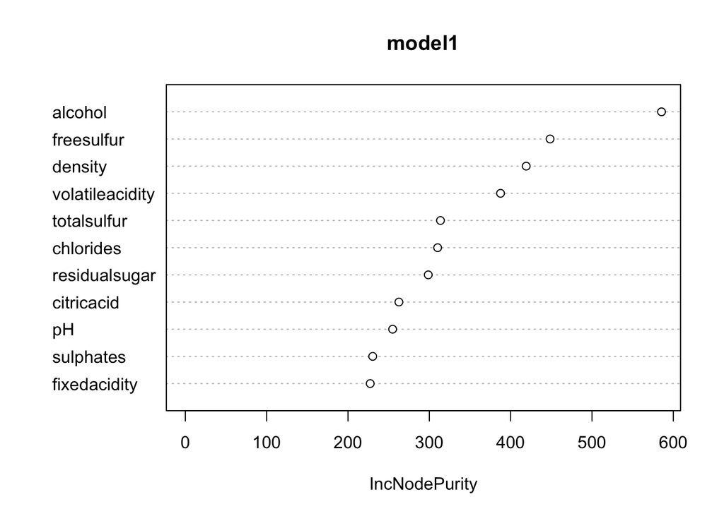

```r
varImpPlot(model1)
```

```r
importance_frame <- measure_importance(model1)
```

```
## [1] "Warning: your forest does not contain information on local importance so 'mse_increase' measure cannot be extracted. To add it regrow the forest with the option localImp = TRUE and run this function again."
```

```r
importance_frame
```

```
##           variable mean_min_depth no_of_nodes node_purity_increase no_of_trees
## 1          alcohol           1.43       11328             585.4727         100
## 2        chlorides           2.29       11927             310.1915         100
## 3       citricacid           2.80       11757             262.5865         100
## 4          density           1.91       12528             419.0974         100
## 5     fixedacidity           3.14       11544             227.2946         100
## 6       freesulfur           1.60       12762             448.4366         100
## 7               pH           3.39       12260             254.8430         100
## 8    residualsugar           2.95       12431             298.6757         100
## 9        sulphates           3.12       12080             230.3496         100
## 10     totalsulfur           2.56       12767             313.6727         100
## 11 volatileacidity           2.28       11568             387.5450         100
##    times_a_root      p_value
## 1            27 1.000000e+00
## 2            22 9.368142e-01
## 3             4 9.992121e-01
## 4            22 1.423943e-05
## 5             1 9.999999e-01
## 6            14 8.423937e-11
## 7             1 4.970182e-02
## 8             1 5.401025e-04
## 9             0 5.262784e-01
## 10            7 6.191852e-11
## 11            1 9.999997e-01
```

B. Classification problem 1. Now you will regroup the outcome variable, quality, into “less-than-average” and “better-than-average” by creating a binary variable. 2. Identify the most important predictors. (Remember it changes in each run!) 3. Use the winner model and the test set, report AUC, uncertainty. What’s its confusion table?

```r
library(PASWR)
library(ROCR)
library(rpart)

average <- mean(white1$quality)

quality1 <-ifelse(white1$quality < average, "less_than_average", "better_than_average")
newdata <- cbind(white1, quality1)
newdata <- newdata[, -12]


newdata$quality1 <- as.factor(newdata$quality1)



df <- newdata #for rpart
dff <- df[complete.cases(df),] # for rf

n <- 5
B <- 1000
AUC1 <- c()
AUC2 <- c()
AUC3 <- c()

for (i in 1:n) {
  ind <- sample(nrow(df), nrow(df), replace = TRUE)
  train <- df[ind, ]
  test <- df[-ind, ]

  ind <- sample(nrow(dff), nrow(dff), replace = TRUE)
  train2 <- dff[ind, ]
  test2 <- dff[-ind, ]

  p = ncol(train2)-1

  model1 <- rpart(quality1~.,
                data=train2, method="class") #cart
  model2 <- randomForest(quality1~.,
                         ntree = B, mtry = p, data = train2) #Bagged
  model3 <- randomForest(quality1~.,
                         ntree = B, data = train2) # RF

  phat1 <- predict(model1, test2, type = "prob")
  phat2 <- predict(model2, test2, type = "prob")
  phat3 <- predict(model3, test2, type = "prob")

  #AUC1
  pred_rocr1 <- prediction(phat1[,2], test2$quality1)
  auc_ROCR1 <- performance(pred_rocr1, measure = "auc")
  AUC1[i] <- auc_ROCR1@y.values[[1]]

  #AUC2
  pred_rocr2 <- prediction(phat2[,2], test2$quality1)
  auc_ROCR2 <- performance(pred_rocr2, measure = "auc")
  AUC2[i] <- auc_ROCR2@y.values[[1]]

  #AUC3
  pred_rocr3 <- prediction(phat3[,2], test2$quality1)
  auc_ROCR3 <- performance(pred_rocr3, measure = "auc")
  AUC3[i] <- auc_ROCR3@y.values[[1]]
}




mean(AUC1)
```

```
## [1] 0.7395514
```

```r
mean(AUC2)
```

```
## [1] 0.8818655
```

```r
mean(AUC3)
```

```
## [1] 0.8937698
```

```r
sd(AUC1)
```

```
## [1] 0.003776359
```

```r
sd(AUC2)
```

```
## [1] 0.003486624
```

```r
sd(AUC3)
```

```
## [1] 0.004109124
```

```r
#uncertainty
UN <- 1-AUC3
UN
```

```
## [1] 0.1128055 0.1034630 0.1077672 0.1035443 0.1035711
```

```r
## aa <- data.frame(phat3)
## aa
##ADD THE CONFUSI0n TABLE
yhat <- ifelse(phat3 > 0.5, 1, 0)

## 5. Build the confusion table.

ct <- table(test2$quality1, yhat[,2])

# This function take `ct` and make a better table
gct <- function(x) {
  conf_table <- matrix(0, 2, 2)
  conf_table[1, 1] <- ifelse(sum(dim(x)) > 3, x[2, 2], 0)
  conf_table[2, 2] <- ifelse(sum(dim(x)) > 3, x[1, 1], 0)
  conf_table[1, 2] <- ifelse(sum(dim(x)) > 3, x[2, 1], 0)
  conf_table[2, 1] <- ifelse(sum(dim(x)) > 3, x[1, 2], 0)
  colnames(conf_table) <- c("Y=1", "Y=0")
  rownames(conf_table) <- c("phat=1", "phat=0")
  conf_table
}

cont <- gct(ct)
cont
```

```
##        Y=1  Y=0
## phat=1 412  201
## phat=0 112 1077
```

```r
##importance
model3$importance
```

```
##                 MeanDecreaseGini
## fixedacidity            149.0694
## volatileacidity         235.0425
## citricacid              181.1519
## residualsugar           182.9895
## chlorides               200.2346
## freesulfur              203.0150
## totalsulfur             188.2446
## density                 239.4773
## pH                      162.4918
## sulphates               141.3475
## alcohol                 301.9838
```

PART 3 This is a classification problem. Append both datasets for white and red wines and create one dataset (make sure that you have an identifier for white and red types). Please report the results for the following steps: 1. The outcome variable is the type (red or white) you created. Use parametric and non-parametric classifiers and select the one that has the best predictive power. 2. Justify your choice of model by AUC and its uncertainty. 3. Identify the most important predictors. 4. What’s the final results using the test data?

```r
## I am using combining my white1 and red1 dataset since its been preprocessed
white1$type <- 1
red1$type <- 0

wine <- rbind(white1, red1)

wine$type <- as.factor(wine$type)


df1 <- wine #for rpart
dff1 <- df1[complete.cases(df1),] # for rf

n <- 5
B <- 1000
AUC4 <- c()
AUC5 <- c()
AUC6 <- c()

for (i in 1:n) {
  ind <- sample(nrow(df1), nrow(df1), replace = TRUE)
  train <- df1[ind, ]
  test <- df1[-ind, ]

  ind <- sample(nrow(dff1), nrow(dff1), replace = TRUE)
  train2 <- dff1[ind, ]
  test2 <- dff1[-ind, ]

  p = ncol(train2)-1

  model4 <- rpart(type~.,
                data=train2, method="class") #cart
  model5 <- randomForest(type~.,
                         ntree = B, mtry = p, data = train2) #Bagged
  model6 <- randomForest(type~.,
                         ntree = B, data = train2) # RF

  phat1 <- predict(model4, test2, type = "prob")
  phat2 <- predict(model5, test2, type = "prob")
  phat3 <- predict(model6, test2, type = "prob")

  #AUC1
  pred_rocr1 <- prediction(phat1[,2], test2$type)
  auc_ROCR1 <- performance(pred_rocr1, measure = "auc")
  AUC4[i] <- auc_ROCR1@y.values[[1]]

  #AUC2
  pred_rocr2 <- prediction(phat2[,2], test2$type)
  auc_ROCR2 <- performance(pred_rocr2, measure = "auc")
  AUC5[i] <- auc_ROCR2@y.values[[1]]

  #AUC3
  pred_rocr3 <- prediction(phat3[,2], test2$type)
  auc_ROCR3 <- performance(pred_rocr3, measure = "auc")
  AUC6[i] <- auc_ROCR3@y.values[[1]]
}

##ADD THE PHAT MATRIX



mean(AUC4)
```

```
## [1] 0.977446
```

```r
mean(AUC5)
```

```
## [1] 0.9965611
```

```r
mean(AUC6)
```

```
## [1] 0.9971965
```

```r
sd(AUC4)
```

```
## [1] 0.007771739
```

```r
sd(AUC5)
```

```
## [1] 0.001324447
```

```r
sd(AUC6)
```

```
## [1] 0.001091193
```

```r
##uncertainty
UN1 <- 1-AUC6
UN1
```

```
## [1] 0.002882963 0.004104954 0.001614752 0.001804257 0.003610407
```

```r
model6$importance
```

```
##                 MeanDecreaseGini
## fixedacidity           99.209416
## volatileacidity       291.825817
## citricacid             67.983148
## residualsugar          98.860191
## chlorides             645.587585
## freesulfur            140.038747
## totalsulfur           687.234769
## density               143.476341
## pH                     57.408377
## sulphates             122.605389
## alcohol                23.541807
## quality                 5.329195
```